# wound_closure_analysis

# Models for healing rate

## Creating the Models

```r
rate_full <- lmer(
  healing_rate ~ fish * wound + (1 | tank),
  data = percent_closure
)
summary(rate_full)
```

```
## Linear mixed model fit by REML ['lmerMod']
## Formula: healing_rate ~ fish * wound + (1 | tank)
##    Data: percent_closure
##
## REML criterion at convergence: -140
##
## Scaled residuals:
##      Min       1Q   Median       3Q      Max
## -2.72955 -0.53791  0.04203  0.56225  2.13584
##
## Random effects:
##  Groups   Name        Variance  Std.Dev.
##  tank     (Intercept) 6.678e-05 0.008172
##  Residual             1.752e-03 0.041852
## Number of obs: 47, groups:  tank, 6
##
## Fixed effects:
##                     Estimate Std. Error t value
## (Intercept)          0.05682    0.01348   4.214
## fishFish             0.02166    0.01871   1.158
## woundLarge           0.07441    0.01748   4.257
## fishFish:woundLarge  0.05077    0.02444   2.077
##
## Correlation of Fixed Effects:
##             (Intr) fshFsh wndLrg
## fishFish    -0.721
## woundLarge  -0.677  0.488
## fshFsh:wndL  0.484 -0.668 -0.715
```

```r
rate_no_interaction <- lmer(
  healing_rate ~ fish + wound + (1 | tank),
  data = percent_closure
)
summary(rate_no_interaction)
```

```
## Linear mixed model fit by REML ['lmerMod']
## Formula: healing_rate ~ fish + wound + (1 | tank)
##    Data: percent_closure
##
## REML criterion at convergence: -141.4
##
## Scaled residuals:
##      Min       1Q   Median       3Q      Max
## -2.91561 -0.51180  0.00246  0.60598  2.36132
##
## Random effects:
##  Groups   Name        Variance  Std.Dev.
##  tank     (Intercept) 0.0000586 0.007655
##  Residual             0.0018910 0.043485
## Number of obs: 47, groups:  tank, 6
##
## Fixed effects:
##             Estimate Std. Error t value
## (Intercept)  0.04329    0.01207   3.586
## fishFish     0.04760    0.01415   3.364
## woundLarge   0.10035    0.01269   7.905
##
## Correlation of Fixed Effects:
##            (Intr) fshFsh
## fishFish   -0.607
## woundLarge -0.549  0.020
```

```r
rate_no_fish <- lmer(
  healing_rate ~ wound + (1 | tank),
  data = percent_closure
)
summary(rate_no_fish)
```

```
## Linear mixed model fit by REML ['lmerMod']
## Formula: healing_rate ~ wound + (1 | tank)
##    Data: percent_closure
##
## REML criterion at convergence: -141.4
##
## Scaled residuals:
##      Min       1Q   Median       3Q      Max
## -2.91451 -0.36869  0.04567  0.49361  2.18835
##
## Random effects:
##  Groups   Name        Variance  Std.Dev.
##  tank     (Intercept) 0.0006804 0.02608
##  Residual             0.0018930 0.04351
## Number of obs: 47, groups:  tank, 6
##
## Fixed effects:
##             Estimate Std. Error t value
## (Intercept)  0.06709    0.01400   4.792
## woundLarge   0.10035    0.01271   7.897
##
## Correlation of Fixed Effects:
##            (Intr)
## woundLarge -0.464
```

```r
rate_no_wound <- lmer(
  healing_rate ~ fish + (1 | tank),
  data = percent_closure
)
```

```
## boundary (singular) fit: see help('isSingular')
```

```r
summary(rate_no_wound)
```

```
## Linear mixed model fit by REML ['lmerMod']
## Formula: healing_rate ~ fish + (1 | tank)
##    Data: percent_closure
##
## REML criterion at convergence: -109
##
## Scaled residuals:
##     Min      1Q  Median      3Q     Max
## -1.3395 -0.8083 -0.3734  0.7848  2.3498
##
## Random effects:
##  Groups   Name        Variance Std.Dev.
##  tank     (Intercept) 0.000000 0.00000
##  Residual             0.004512 0.06717
## Number of obs: 47, groups:  tank, 6
##
## Fixed effects:
##             Estimate Std. Error t value
## (Intercept)  0.09575    0.01401   6.836
## fishFish     0.04532    0.01960   2.312
##
## Correlation of Fixed Effects:
##          (Intr)
## fishFish -0.715
## optimizer (nloptwrap) convergence code: 0 (OK)
## boundary (singular) fit: see help('isSingular')
```

```r
# Likelihood ratio tests for healing rate
lrt_interaction_zero_rate <- anova(rate_no_interaction, rate_full, test = "Chisq")
```

```
## refitting model(s) with ML (instead of REML)
```

```r
lrt_fish_zero_rate <- anova(rate_no_fish, rate_no_interaction, test = "Chisq")
```

```
## refitting model(s) with ML (instead of REML)
```

```r
lrt_wound_zero_rate <- anova(rate_no_wound, rate_no_interaction, test = "Chisq")
```

```
## refitting model(s) with ML (instead of REML)
```

```r
lrt_table_rate <- tibble(
  Test = c("Interaction (Fish × Wound)", "Fish Effect", "Wound Effect"),
  ChiSq = c(lrt_interaction_zero_rate$Chisq[2],
            lrt_fish_zero_rate$Chisq[2],
            lrt_wound_zero_rate$Chisq[2]),
  Df = c(lrt_interaction_zero_rate$Df[2],
         lrt_fish_zero_rate$Df[2],
         lrt_wound_zero_rate$Df[2]),
  p_value = c(lrt_interaction_zero_rate$`Pr(>Chisq)`[2],
              lrt_fish_zero_rate$`Pr(>Chisq)`[2],
              lrt_wound_zero_rate$`Pr(>Chisq)`[2])
) %>%
  mutate(across(where(is.numeric), round, 3))

# Format with gt
gt_table_rate <- lrt_table_rate %>%
  gt() %>%
  tab_header(
    title = "Table #. Likelihood Ratio Tests for Effects on Healing Rate"
  ) %>%
  cols_label(
    Test = "Model Comparison",
    ChiSq = "Chi-squared",
    Df = "Degrees of Freedom",
    p_value = "P-value"
  ) %>%
  fmt_number(columns = vars(ChiSq, p_value), decimals = 3) %>%
  tab_options(
    table.font.size = 14,
    heading.title.font.size = 16,
    heading.subtitle.font.size = 13
  )
print(gt_table_rate)
```

[output not shown]

[output cut: 425 more lines]

[output not shown]

```r
gtsave(gt_table_rate, here("figures","lrt_table_rate.html"))

# Interpretation note:
# Significant p-values (p < 0.05) indicate an effect of fish presence or wound size on healing rate.
```

# ——————————————–

# Diagnostics for Healing Rate Models

# ——————————————–

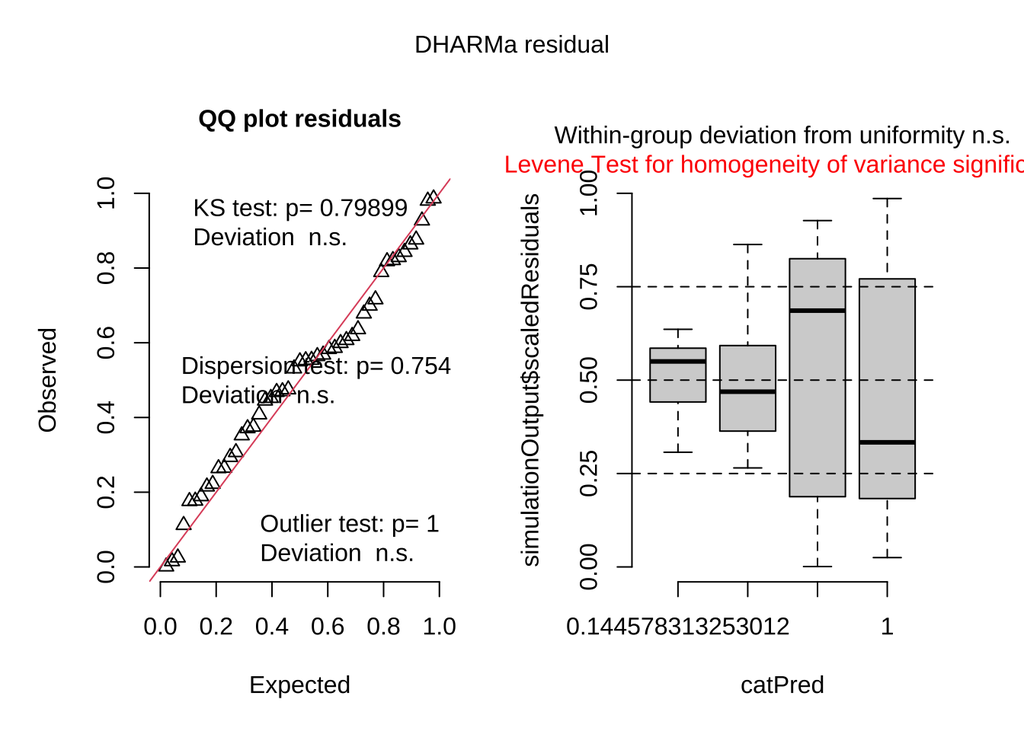

```r
library(DHARMa)
library(patchwork)

## 1. Residual diagnostics for full model
sim_rate_full <- simulateResiduals(fittedModel = rate_full, n = 1000)
p_dharma_full <- plot(sim_rate_full)   # QQ-plot, residual vs fitted, outliers
```

```r
ggsave(
  here("figures", "diagnostics", "sim_rate_full.png"),
  p_dharma_full,
  width = 7, height = 6, dpi = 300
)

# Optional: test for dispersion and zero-inflation
cat("\nDispersion test for full model:\n")
```

```
##
## Dispersion test for full model:
```

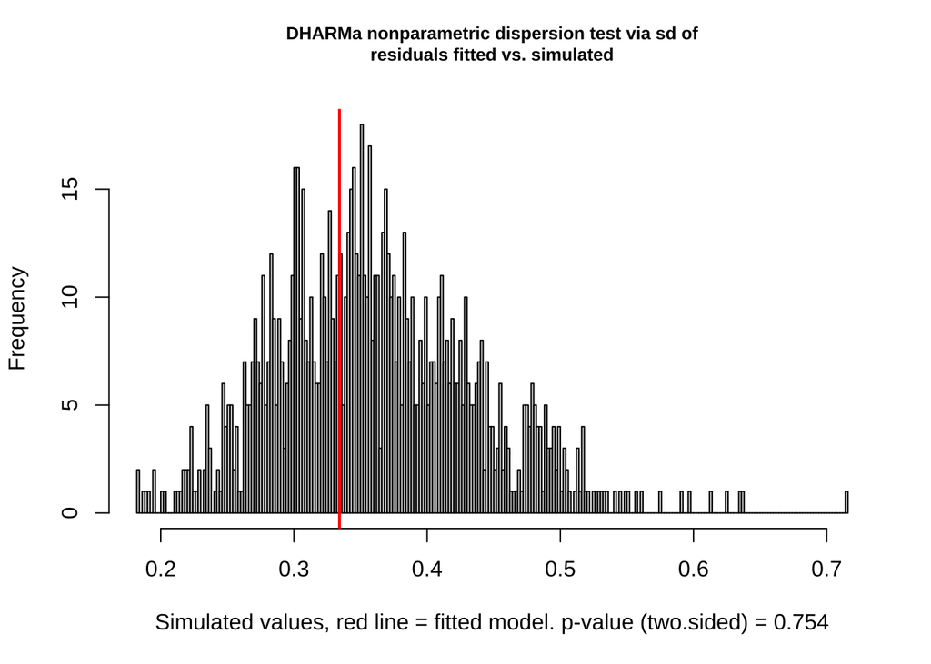

```
##
##  DHARMa nonparametric dispersion test via sd of residuals fitted vs.
##  simulated
##
## data:  simulationOutput
## dispersion = 0.92535, p-value = 0.754
## alternative hypothesis: two.sided
```

```r
print(testDispersion(sim_rate_full))
```

```r
cat("\nZero-inflation test for full model:\n")
```

```
##
## Zero-inflation test for full model:
```

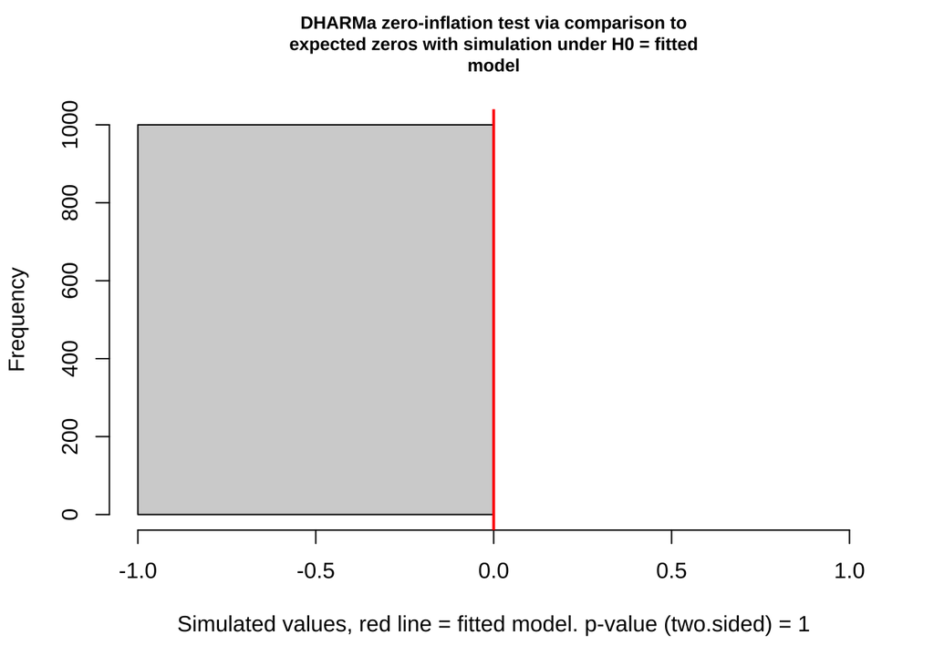

```
##
##  DHARMa zero-inflation test via comparison to expected zeros with
##  simulation under H0 = fitted model
##
## data:  simulationOutput
## ratioObsSim = NaN, p-value = 1
## alternative hypothesis: two.sided
```

```r
print(testZeroInflation(sim_rate_full))
```

```
##
## ---- Diagnostics for Full model ----
```

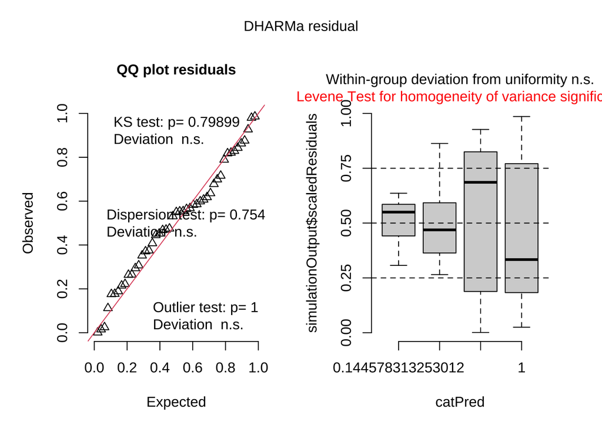

```
##
## ---- Diagnostics for NoInteraction model ----
```

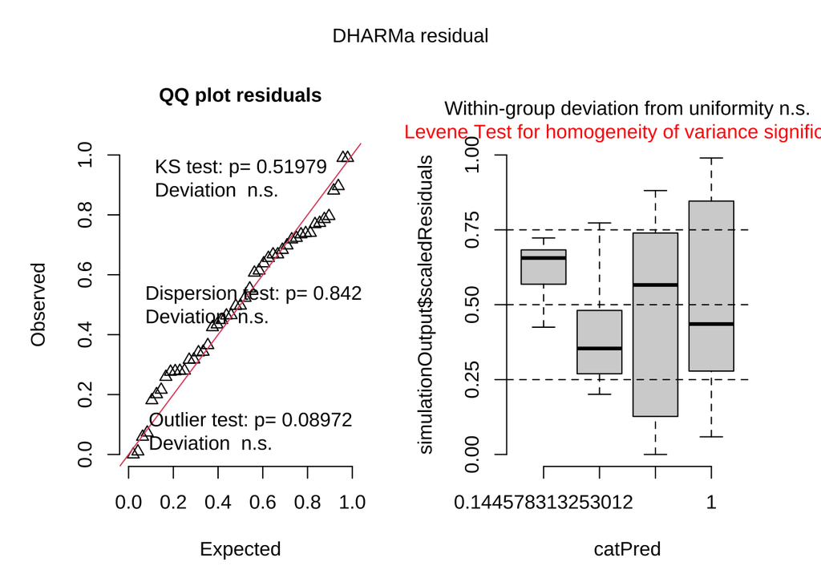

```
##
## ---- Diagnostics for NoFish model ----
```

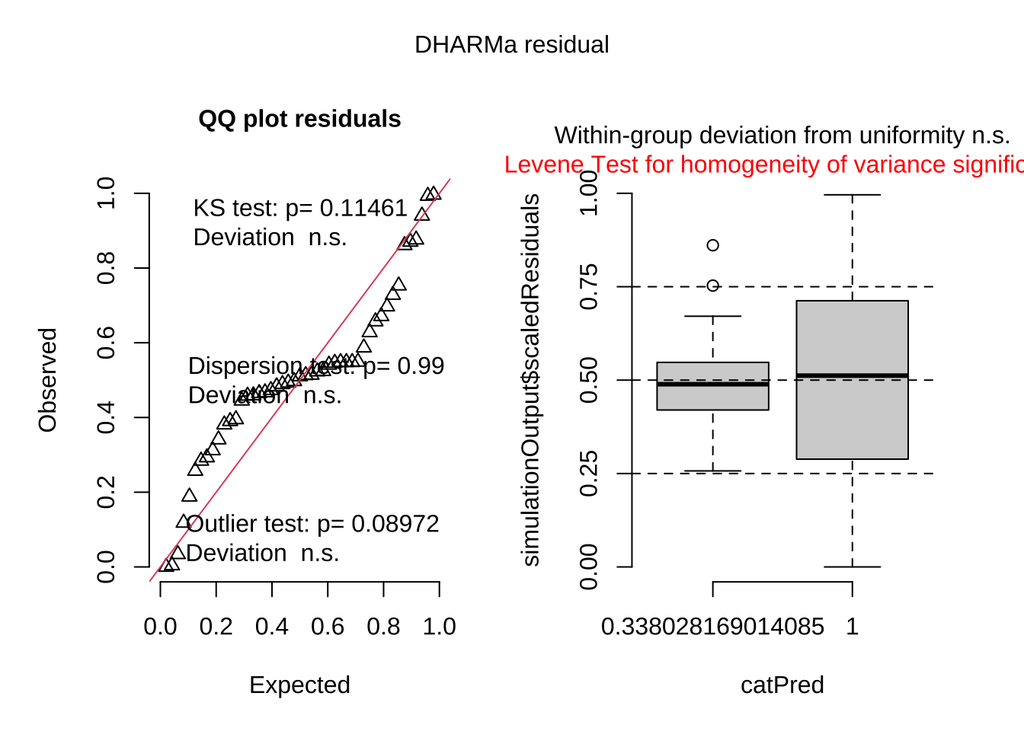

```
##
## ---- Diagnostics for NoWound model ----
```

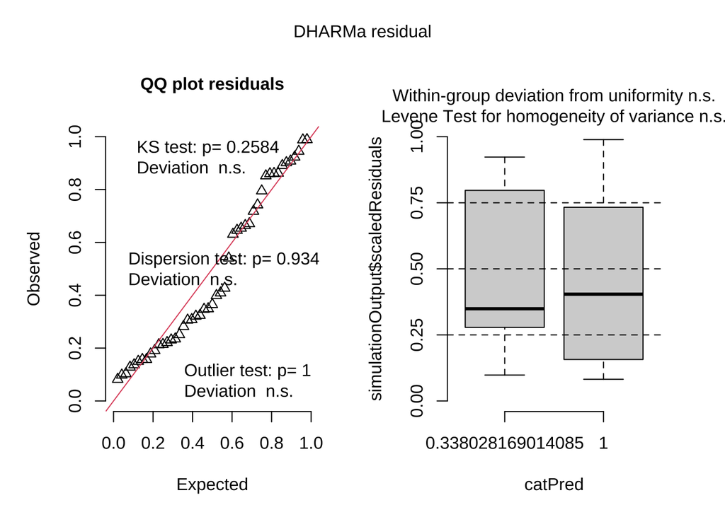

```r
## 2. Compare residuals across all candidate models
model_list <- list(
  Full = rate_full,
  NoInteraction = rate_no_interaction,
  NoFish = rate_no_fish,
  NoWound = rate_no_wound
)

for (nm in names(model_list)) {
  cat("\n---- Diagnostics for", nm, "model ----\n")
  sim <- simulateResiduals(model_list[[nm]], n = 1000)
  p <- plot(sim)
  ggsave(
    here("figures", "diagnostics", paste0("resid_", nm, ".png")),
    p,
    width = 7, height = 6, dpi = 300
  )
}
```

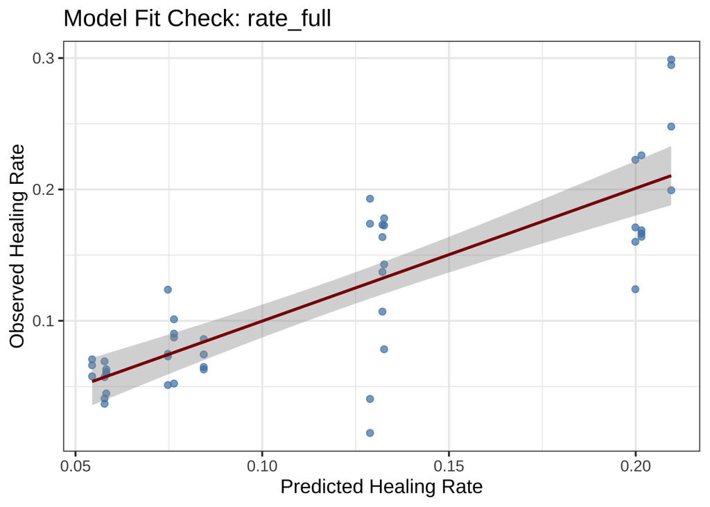

```r
## 3. Predicted vs observed scatterplot
percent_closure$pred_full <- predict(rate_full)

p_fit <- ggplot(percent_closure, aes(x = pred_full, y = healing_rate)) +
  geom_point(color = "steelblue", size = 2, alpha = 0.7) +
  geom_smooth(method = "lm", se = TRUE, color = "darkred") +
  labs(
    x = "Predicted Healing Rate",
    y = "Observed Healing Rate",
    title = "Model Fit Check: rate_full"
  ) +
  theme_bw(base_size = 14)

print(p_fit)
```

```r
ggsave(
  here("figures", "diagnostics", "fit_scatterplot.png"),
  p_fit,
  width = 7, height = 6, dpi = 300
)
## 4. Publication-quality residuals panel
# Explicit ggplot diagnostics for residuals
p_resid_plot <- ggplot(
  data.frame(resid = residuals(rate_full, type = "pearson")),
  aes(x = seq_along(resid), y = resid)
) +
  geom_point(alpha = 0.6) +
  geom_hline(yintercept = 0, linetype = "dashed") +
  theme_minimal() +
  labs(title = "Pearson Residuals", x = "Observation", y = "Residual")

p_fit_plot <- ggplot(
  data.frame(fitted = fitted(rate_full),
             resid = residuals(rate_full, type = "pearson")),
  aes(x = fitted, y = resid)
) +
  geom_point(alpha = 0.6) +
  geom_hline(yintercept = 0, linetype = "dashed") +
  theme_minimal() +
  labs(title = "Residuals vs Fitted", x = "Fitted values", y = "Residuals")

# Combine into panel
p_resid_panel <- (p_resid_plot | p_fit_plot) +
  plot_annotation(
    title = "Residual Diagnostics for Healing Rate Models",
    theme = theme(plot.title = element_text(size = 18, face = "bold"))
  )

# Save panel
ggsave(
  here("figures","diagnostics","healing_rate_diagnostics_panel.png"),
  p_resid_panel,
  width = 10, height = 5, dpi = 300, bg = "white"
)
```

## Publication-quality Visualization: Healing Rate by Fish × Wound

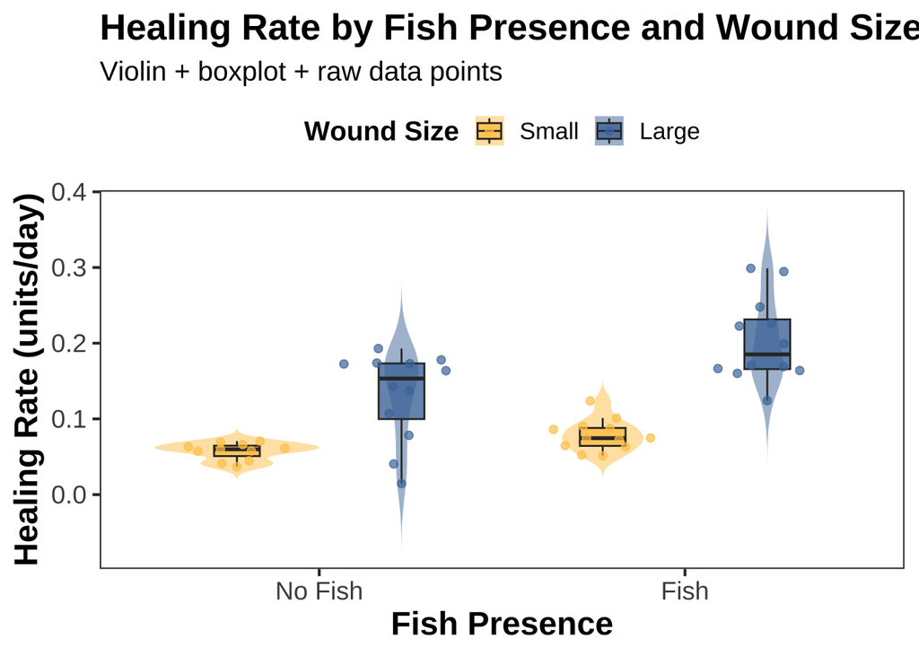

```r
## Publication-quality Visualization: Healing Rate by Fish × Wound
library(ggbeeswarm)   # better jitter (quasirandom) for raw data

p_rate <- ggplot(percent_closure, aes(fish, healing_rate, fill = wound)) +
  # Violin plot to show distribution
  geom_violin(trim = FALSE, alpha = 0.5, color = NA, width = 0.9) +
  # Boxplot for medians and IQR
  geom_boxplot(width = 0.25, outlier.shape = NA, alpha = 0.8, position = position_dodge(width = 0.9)) +
  # Raw datapoints (jittered)
  geom_quasirandom(aes(color = wound), size = 1.8, alpha = 0.7, dodge.width = 0.9) +
  # Labels and titles
  labs(
    x = "Fish Presence",
    y = "Healing Rate (units/day)",
    fill = "Wound Size",
    color = "Wound Size",
    title = "Healing Rate by Fish Presence and Wound Size",
    subtitle = "Violin + boxplot + raw data points"
  ) +
  # Nicer palette
  scale_fill_manual(values = c("Small" = "#FFC857", "Large" = "#4C78A8")) +
  scale_color_manual(values = c("Small" = "#FFC857", "Large" = "#4C78A8")) +
  # Theme for clarity
  theme_bw(base_size = 16) +
  theme(
    panel.grid = element_blank(),
    axis.title = element_text(size = 18, face = "bold"),
    axis.text = element_text(size = 14),
    legend.position = "top",
    legend.title = element_text(size = 15, face = "bold"),
    legend.text = element_text(size = 13),
    plot.title = element_text(size = 20, face = "bold"),
    plot.subtitle = element_text(size = 15)
  )

print(p_rate)
```

```r
ggsave(
  here("figures", "healing_rate_violin_boxplot_points.png"),
  p_rate,
  width = 7, height = 6, dpi = 600, bg = "white"
)
```

## Publication-quality Visualization: Interaction Effect

# This plot highlights the interaction between fish presence and wound size

# by showing estimated marginal means (predicted healing rates with CI).

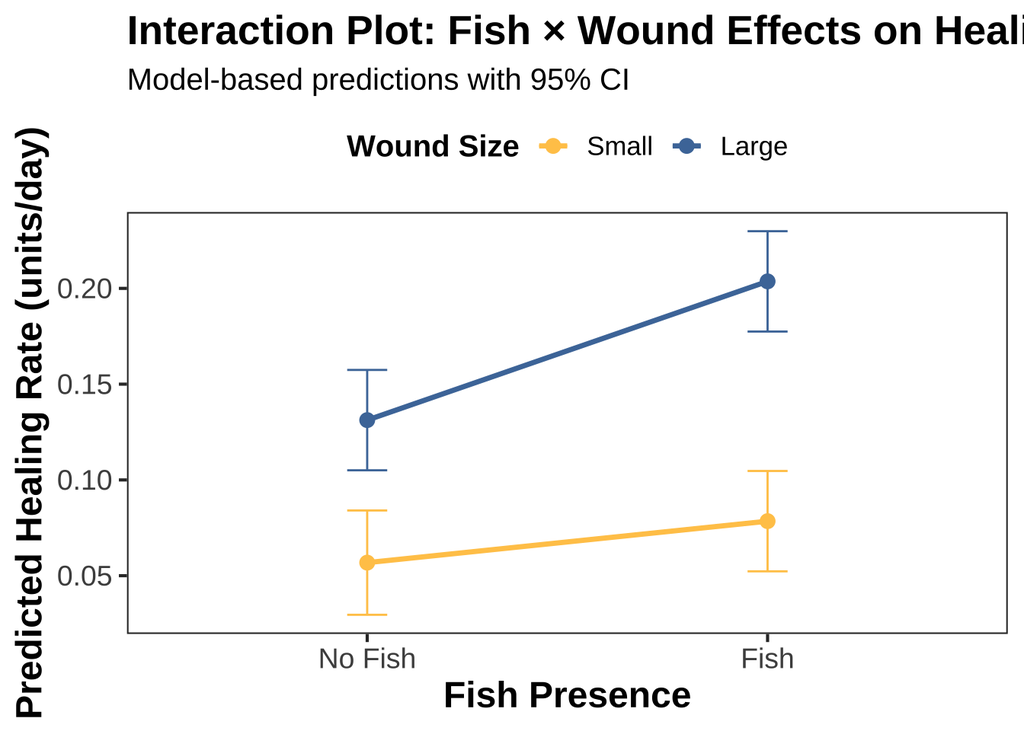

```r
library(ggeffects)

# Get predicted values from the full model
pred_rate <- ggpredict(rate_full, terms = c("fish", "wound"))

p_rate_interaction <- ggplot(pred_rate, aes(x = x, y = predicted,
                                            color = group, group = group)) +
  geom_line(size = 1.2) +
  geom_point(size = 3) +
  geom_errorbar(aes(ymin = conf.low, ymax = conf.high), width = 0.1) +
  labs(
    x = "Fish Presence",
    y = "Predicted Healing Rate (units/day)",
    color = "Wound Size",
    title = "Interaction Plot: Fish × Wound Effects on Healing Rate",
    subtitle = "Model-based predictions with 95% CI"
  ) +
  scale_color_manual(values = c("Small" = "#FFC857", "Large" = "#4C78A8")) +
  theme_bw(base_size = 16) +
  theme(
    panel.grid = element_blank(),
    axis.title = element_text(size = 18, face = "bold"),
    axis.text = element_text(size = 14),
    legend.position = "top",
    legend.title = element_text(size = 15, face = "bold"),
    legend.text = element_text(size = 13),
    plot.title = element_text(size = 20, face = "bold"),
    plot.subtitle = element_text(size = 15)
  )
print(p_rate_interaction)
```

```r
ggsave(
  here("figures", "healing_rate_interaction_plot.png"),
  p_rate_interaction,
  width = 7, height = 6, dpi = 600, bg = "white"
)
```

# =============================== # Chunk 8: Model Fit and R² Values # =============================== # Purpose: # Evaluate overall model performance and variance explained # for the healing rate mixed models. # # Approach: # - Use MuMIn::r.squaredGLMM() to extract: # * Marginal R² = variance explained by fixed effects # * Conditional R² = variance explained by fixed + random effects # # Interpretation: # - Marginal R² shows contribution of predictors (fish, wound, interaction). # - Conditional R² includes tank-level variation. # # Reproducibility: # - Printing R² ensures results are visible in the knitted output. # - Useful for comparing models and justifying inclusion of predictors. ## R2 values

```r
r2_full <- r.squaredGLMM(rate_full)
print(r2_full)
```

```
##            R2m       R2c
## [1,] 0.6420373 0.6551844
```

# ===============================

# Chunk 9: Exploratory / Rough Code

# ===============================

# Purpose:

# Test alternative model structures for wound healing outcomes.

# This section includes exploratory analyses that are *not finalized*

# for the manuscript but retained here for transparency and reproducibility.

# Approach:

# - Alternative GLMM and glmmTMB specifications for proportion healed

# - Variants of zero-inflated beta regression models

# - GAMLSS models (beta-inflated distributions) as robustness checks

# Notes:

# - Some models may not converge or may give counterintuitive results

# - AIC and likelihood comparisons are used for exploratory model selection

# - These analyses are labeled “rough” to clearly separate from

# the core manuscript-ready models

# Reproducibility:

# - Keep all exploratory models commented or clearly sectioned

# - Document reasons for discarding or mistrusting certain models

# - Useful for lab records and for re-examining decisions in the future

# Rough code

### figuring which model to use for final wound healing

```r
#modeling proportion of the wound remaining at Tf, this gets around the 1 inflation, and allows for 0 inflation, which glmmTMB can deal with.
percent_closure$prop_remaining <- 1 - percent_closure$prop

beta_mod <- glmmTMB(
  prop_remaining ~ fish * wound + (1 | tank),
  ziformula = ~ fish * wound,
  data = percent_closure,
  family = beta_family(link = "logit")
)
summary(beta_mod)
```

```
##  Family: beta  ( logit )
## Formula:          prop_remaining ~ fish * wound + (1 | tank)
## Zero inflation:                  ~fish * wound
## Data: percent_closure
##
##       AIC       BIC    logLik -2*log(L)  df.resid
##      38.9      57.4      -9.5      18.9        37
##
## Random effects:
##
## Conditional model:
##  Groups Name        Variance  Std.Dev.
##  tank   (Intercept) 2.788e-10 1.67e-05
## Number of obs: 47, groups:  tank, 6
##
## Dispersion parameter for beta family (): 3.61
##
## Conditional model:
##                     Estimate Std. Error z value Pr(>|z|)
## (Intercept)          -1.5486     0.4672  -3.315 0.000918 ***
## fishFish             -0.7515     0.6805  -1.104 0.269417
## woundLarge            0.3098     0.5501   0.563 0.573276
## fishFish:woundLarge   0.3872     0.9009   0.430 0.667394
## ---
## Signif. codes:  0 '***' 0.001 '**' 0.01 '*' 0.05 '.' 0.1 ' ' 1
##
## Zero-inflation model:
##                     Estimate Std. Error z value Pr(>|z|)
## (Intercept)           0.1823     0.6055   0.301    0.763
## fishFish              0.5108     0.8612   0.593    0.553
## woundLarge           -1.2809     0.9006  -1.422    0.155
## fishFish:woundLarge   1.2809     1.2494   1.025    0.305
```

```r
beta_mod_null<- glmmTMB(
  prop_remaining ~ fish * wound + (1 | tank),
  ziformula = ~1,
  data = percent_closure,
  family = beta_family(link = "logit")
)
summary(beta_mod_null)
```

```
##  Family: beta  ( logit )
## Formula:          prop_remaining ~ fish * wound + (1 | tank)
## Zero inflation:                  ~1
## Data: percent_closure
##
##       AIC       BIC    logLik -2*log(L)  df.resid
##      38.7      51.6     -12.3      24.7        40
##
## Random effects:
##
## Conditional model:
##  Groups Name        Variance  Std.Dev.
##  tank   (Intercept) 2.228e-10 1.493e-05
## Number of obs: 47, groups:  tank, 6
##
## Dispersion parameter for beta family (): 3.61
##
## Conditional model:
##                     Estimate Std. Error z value Pr(>|z|)
## (Intercept)          -1.5486     0.4672  -3.315 0.000918 ***
## fishFish             -0.7515     0.6805  -1.104 0.269417
## woundLarge            0.3098     0.5501   0.563 0.573276
## fishFish:woundLarge   0.3872     0.9009   0.430 0.667394
## ---
## Signif. codes:  0 '***' 0.001 '**' 0.01 '*' 0.05 '.' 0.1 ' ' 1
##
## Zero-inflation model:
##             Estimate Std. Error z value Pr(>|z|)
## (Intercept)   0.1278     0.2923   0.437    0.662
```

```r
beta_mod_fix<- glmmTMB(
  prop_remaining ~ fish * wound + (1 | tank),
  ziformula = ~fish + wound,
  data = percent_closure,
  family = beta_family(link = "logit")
)
summary(beta_mod_fix)
```

```
##  Family: beta  ( logit )
## Formula:          prop_remaining ~ fish * wound + (1 | tank)
## Zero inflation:                  ~fish + wound
## Data: percent_closure
##
##       AIC       BIC    logLik -2*log(L)  df.resid
##      38.0      54.7     -10.0      20.0        38
##
## Random effects:
##
## Conditional model:
##  Groups Name        Variance  Std.Dev.
##  tank   (Intercept) 2.277e-10 1.509e-05
## Number of obs: 47, groups:  tank, 6
##
## Dispersion parameter for beta family (): 3.61
##
## Conditional model:
##                     Estimate Std. Error z value Pr(>|z|)
## (Intercept)          -1.5486     0.4672  -3.315 0.000918 ***
## fishFish             -0.7515     0.6805  -1.104 0.269417
## woundLarge            0.3098     0.5501   0.563 0.573276
## fishFish:woundLarge   0.3872     0.9009   0.430 0.667394
## ---
## Signif. codes:  0 '***' 0.001 '**' 0.01 '*' 0.05 '.' 0.1 ' ' 1
##
## Zero-inflation model:
##             Estimate Std. Error z value Pr(>|z|)
## (Intercept)  -0.1221     0.5268  -0.232   0.8168
## fishFish      1.1488     0.6166   1.863   0.0625 .
## woundLarge   -0.6335     0.6171  -1.026   0.3046
## ---
## Signif. codes:  0 '***' 0.001 '**' 0.01 '*' 0.05 '.' 0.1 ' ' 1
```

```r
beta_mod_fish<- glmmTMB(
  prop_remaining ~ fish * wound + (1 | tank),
  ziformula = ~fish,
  data = percent_closure,
  family = beta_family(link = "logit")
)
summary(beta_mod_fish)
```

```
##  Family: beta  ( logit )
## Formula:          prop_remaining ~ fish * wound + (1 | tank)
## Zero inflation:                  ~fish
## Data: percent_closure
##
##       AIC       BIC    logLik -2*log(L)  df.resid
##      37.1      51.9     -10.5      21.1        39
##
## Random effects:
##
## Conditional model:
##  Groups Name        Variance  Std.Dev.
##  tank   (Intercept) 2.078e-10 1.441e-05
## Number of obs: 47, groups:  tank, 6
##
## Dispersion parameter for beta family (): 3.61
##
## Conditional model:
##                     Estimate Std. Error z value Pr(>|z|)
## (Intercept)          -1.5486     0.4672  -3.315 0.000918 ***
## fishFish             -0.7515     0.6805  -1.104 0.269417
## woundLarge            0.3098     0.5501   0.563 0.573276
## fishFish:woundLarge   0.3872     0.9009   0.430 0.667394
## ---
## Signif. codes:  0 '***' 0.001 '**' 0.01 '*' 0.05 '.' 0.1 ' ' 1
##
## Zero-inflation model:
##             Estimate Std. Error z value Pr(>|z|)
## (Intercept)  -0.4418     0.4272  -1.034   0.3011
## fishFish      1.1350     0.6083   1.866   0.0621 .
## ---
## Signif. codes:  0 '***' 0.001 '**' 0.01 '*' 0.05 '.' 0.1 ' ' 1
```

```r
AIC(beta_mod_null, beta_mod)
```

```
##               df      AIC
## beta_mod_null  7 38.69491
## beta_mod      10 38.93762
```

```r
AIC(beta_mod_fish, beta_mod_fix)
```

```
##               df      AIC
## beta_mod_fish  8 37.07246
## beta_mod_fix   9 38.00329
```

```r
#
# NOTE: The gamlss and gamlss.dist packages are required for the BEINF models below.
# The setup chunk will attempt to install them if they are not already available.
#GAMLSS analysis...I don't trust any of these models. Partly because I proabably don't understand and because they're not giving me the values I want :(
beta_prop_1 <- gamlss(
  prop ~ fish * wound + random(tank),
  sigma.fo = ~1,
  nu.fo    = ~1,
  tau.fo   = ~ fish * wound,
  family   = BEINF,
  data     = percent_closure
)
```

```
## GAMLSS-RS iteration 1: Global Deviance = 17.2632
## GAMLSS-RS iteration 2: Global Deviance = 16.982
## GAMLSS-RS iteration 3: Global Deviance = 16.8947
## GAMLSS-RS iteration 4: Global Deviance = 16.8681
## GAMLSS-RS iteration 5: Global Deviance = 16.8589
## GAMLSS-RS iteration 6: Global Deviance = 16.8559
## GAMLSS-RS iteration 7: Global Deviance = 16.8553
```

```r
summary(beta_prop_1)
```

```
## Family:  c("BEINF", "Beta Inflated")
##
## Call:  gamlss(formula = prop ~ fish * wound + random(tank),
##     sigma.formula = ~1, nu.formula = ~1, tau.formula = ~fish *
##         wound, family = BEINF, data = percent_closure)
##
## Fitting method: RS()
##
## ------------------------------------------------------------------
## Mu link function:  logit
## Mu Coefficients:
##                     Estimate Std. Error t value Pr(>|t|)
## (Intercept)           1.1811     0.3230   3.656 0.000835 ***
## fishFish              0.4577     0.5802   0.789 0.435536
## woundSmall            0.3714     0.5424   0.685 0.497998
## fishFish:woundSmall   0.3718     0.8877   0.419 0.677914
## ---
## Signif. codes:  0 '***' 0.001 '**' 0.01 '*' 0.05 '.' 0.1 ' ' 1
##
## ------------------------------------------------------------------
## Sigma link function:  logit
## Sigma Coefficients:
##             Estimate Std. Error t value Pr(>|t|)
## (Intercept)  -0.2056     0.2240  -0.918    0.365
##
## ------------------------------------------------------------------
## Nu link function:  log
## Nu Coefficients:
##             Estimate Std. Error t value Pr(>|t|)
## (Intercept)   -18.54    2272.59  -0.008    0.994
##
## ------------------------------------------------------------------
## Tau link function:  log
## Tau Coefficients:
##                     Estimate Std. Error t value Pr(>|t|)
## (Intercept)          -1.0986     0.6667  -1.648   0.1083
## fishFish              1.7918     0.9052   1.979   0.0557 .
## woundSmall            1.2809     0.9006   1.422   0.1638
## fishFish:woundSmall  -1.2809     1.2494  -1.025   0.3123
## ---
## Signif. codes:  0 '***' 0.001 '**' 0.01 '*' 0.05 '.' 0.1 ' ' 1
##
## ------------------------------------------------------------------
## NOTE: Additive smoothing terms exist in the formulas:
##  i) Std. Error for smoothers are for the linear effect only.
## ii) Std. Error for the linear terms maybe are not accurate.
## ------------------------------------------------------------------
## No. of observations in the fit:  47
## Degrees of Freedom for the fit:  12.07658
##       Residual Deg. of Freedom:  34.92342
##                       at cycle:  7
##
## Global Deviance:     16.85528
##             AIC:     41.00843
##             SBC:     63.35188
```

```r
mod <- gamlss(
  prop ~ fish * wound + random(tank),
  family = BEINF,
  data = percent_closure
)
```

```
## GAMLSS-RS iteration 1: Global Deviance = 23.0205
## GAMLSS-RS iteration 2: Global Deviance = 22.7393
## GAMLSS-RS iteration 3: Global Deviance = 22.652
## GAMLSS-RS iteration 4: Global Deviance = 22.6254
## GAMLSS-RS iteration 5: Global Deviance = 22.6162
## GAMLSS-RS iteration 6: Global Deviance = 22.6132
## GAMLSS-RS iteration 7: Global Deviance = 22.6126
```

```r
summary(mod)
```

```
## Family:  c("BEINF", "Beta Inflated")
##
## Call:  gamlss(formula = prop ~ fish * wound + random(tank),
##     family = BEINF, data = percent_closure)
##
## Fitting method: RS()
##
## ------------------------------------------------------------------
## Mu link function:  logit
## Mu Coefficients:
##                     Estimate Std. Error t value Pr(>|t|)
## (Intercept)           1.1811     0.3230   3.656 0.000773 ***
## fishFish              0.4577     0.5802   0.789 0.435117
## woundSmall            0.3714     0.5424   0.685 0.497642
## fishFish:woundSmall   0.3718     0.8877   0.419 0.677712
## ---
## Signif. codes:  0 '***' 0.001 '**' 0.01 '*' 0.05 '.' 0.1 ' ' 1
##
## ------------------------------------------------------------------
## Sigma link function:  logit
## Sigma Coefficients:
##             Estimate Std. Error t value Pr(>|t|)
## (Intercept)  -0.2056     0.2240  -0.918    0.364
##
## ------------------------------------------------------------------
## Nu link function:  log
## Nu Coefficients:
##             Estimate Std. Error t value Pr(>|t|)
## (Intercept)   -18.54    2257.12  -0.008    0.993
##
## ------------------------------------------------------------------
## Tau link function:  log
## Tau Coefficients:
##             Estimate Std. Error t value Pr(>|t|)
## (Intercept)   0.1278     0.2923   0.437    0.664
##
## ------------------------------------------------------------------
## NOTE: Additive smoothing terms exist in the formulas:
##  i) Std. Error for smoothers are for the linear effect only.
## ii) Std. Error for the linear terms maybe are not accurate.
## ------------------------------------------------------------------
## No. of observations in the fit:  47
## Degrees of Freedom for the fit:  9.076576
##       Residual Deg. of Freedom:  37.92342
##                       at cycle:  7
##
## Global Deviance:     22.61257
##             AIC:     40.76572
##             SBC:     57.55873
```

```r
beta_prop_null <- gamlss(
  prop ~ fish * wound + random(tank),
  sigma.fo = ~1,
  nu.fo    = ~1,
  tau.fo   = ~1,
  family   = BEINF,
  data     = percent_closure
)
```

```
## GAMLSS-RS iteration 1: Global Deviance = 23.0205
## GAMLSS-RS iteration 2: Global Deviance = 22.7393
## GAMLSS-RS iteration 3: Global Deviance = 22.652
## GAMLSS-RS iteration 4: Global Deviance = 22.6254
## GAMLSS-RS iteration 5: Global Deviance = 22.6162
## GAMLSS-RS iteration 6: Global Deviance = 22.6132
## GAMLSS-RS iteration 7: Global Deviance = 22.6126
```

```r
summary(beta_prop_null)
```

```
## Family:  c("BEINF", "Beta Inflated")
##
## Call:  gamlss(formula = prop ~ fish * wound + random(tank),
##     sigma.formula = ~1, nu.formula = ~1, tau.formula = ~1,
##     family = BEINF, data = percent_closure)
##
## Fitting method: RS()
##
## ------------------------------------------------------------------
## Mu link function:  logit
## Mu Coefficients:
##                     Estimate Std. Error t value Pr(>|t|)
## (Intercept)           1.1811     0.3230   3.656 0.000773 ***
## fishFish              0.4577     0.5802   0.789 0.435117
## woundSmall            0.3714     0.5424   0.685 0.497642
## fishFish:woundSmall   0.3718     0.8877   0.419 0.677712
## ---
## Signif. codes:  0 '***' 0.001 '**' 0.01 '*' 0.05 '.' 0.1 ' ' 1
##
## ------------------------------------------------------------------
## Sigma link function:  logit
## Sigma Coefficients:
##             Estimate Std. Error t value Pr(>|t|)
## (Intercept)  -0.2056     0.2240  -0.918    0.364
##
## ------------------------------------------------------------------
## Nu link function:  log
## Nu Coefficients:
##             Estimate Std. Error t value Pr(>|t|)
## (Intercept)   -18.54    2257.12  -0.008    0.993
##
## ------------------------------------------------------------------
## Tau link function:  log
## Tau Coefficients:
##             Estimate Std. Error t value Pr(>|t|)
## (Intercept)   0.1278     0.2923   0.437    0.664
##
## ------------------------------------------------------------------
## NOTE: Additive smoothing terms exist in the formulas:
##  i) Std. Error for smoothers are for the linear effect only.
## ii) Std. Error for the linear terms maybe are not accurate.
## ------------------------------------------------------------------
## No. of observations in the fit:  47
## Degrees of Freedom for the fit:  9.076576
##       Residual Deg. of Freedom:  37.92342
##                       at cycle:  7
##
## Global Deviance:     22.61257
##             AIC:     40.76572
##             SBC:     57.55873
```

```r
# anova() is not supported for GAMLSS models with BEINF family; use AIC for model comparison instead.
# Compare models using AIC for GAMLSS models (anova() not supported)
AIC(beta_prop_1, beta_prop_null)
```

```
##                       df      AIC
## beta_prop_null  9.076576 40.76572
## beta_prop_1    12.076576 41.00843
```

### zero - model comparisons

```r
mod_full_zero <- glmmTMB(
  prop_remaining ~ fish * wound + (1 | tank),
  ziformula = ~ fish * wound,
  data = percent_closure,
  family = beta_family(link = "logit")
)
summary(mod_full_zero)
```

```
##  Family: beta  ( logit )
## Formula:          prop_remaining ~ fish * wound + (1 | tank)
## Zero inflation:                  ~fish * wound
## Data: percent_closure
##
##       AIC       BIC    logLik -2*log(L)  df.resid
##      38.9      57.4      -9.5      18.9        37
##
## Random effects:
##
## Conditional model:
##  Groups Name        Variance  Std.Dev.
##  tank   (Intercept) 2.788e-10 1.67e-05
## Number of obs: 47, groups:  tank, 6
##
## Dispersion parameter for beta family (): 3.61
##
## Conditional model:
##                     Estimate Std. Error z value Pr(>|z|)
## (Intercept)          -1.5486     0.4672  -3.315 0.000918 ***
## fishFish             -0.7515     0.6805  -1.104 0.269417
## woundLarge            0.3098     0.5501   0.563 0.573276
## fishFish:woundLarge   0.3872     0.9009   0.430 0.667394
## ---
## Signif. codes:  0 '***' 0.001 '**' 0.01 '*' 0.05 '.' 0.1 ' ' 1
##
## Zero-inflation model:
##                     Estimate Std. Error z value Pr(>|z|)
## (Intercept)           0.1823     0.6055   0.301    0.763
## fishFish              0.5108     0.8612   0.593    0.553
## woundLarge           -1.2809     0.9006  -1.422    0.155
## fishFish:woundLarge   1.2809     1.2494   1.025    0.305
```

```r
mod_no_interaction_zero <- glmmTMB(
  prop_remaining ~ fish * wound + (1 | tank),
  ziformula = ~ fish + wound,
  data = percent_closure,
  family = beta_family(link = "logit")
)
summary(mod_no_interaction_zero)
```

```
##  Family: beta  ( logit )
## Formula:          prop_remaining ~ fish * wound + (1 | tank)
## Zero inflation:                  ~fish + wound
## Data: percent_closure
##
##       AIC       BIC    logLik -2*log(L)  df.resid
##      38.0      54.7     -10.0      20.0        38
##
## Random effects:
##
## Conditional model:
##  Groups Name        Variance  Std.Dev.
##  tank   (Intercept) 2.277e-10 1.509e-05
## Number of obs: 47, groups:  tank, 6
##
## Dispersion parameter for beta family (): 3.61
##
## Conditional model:
##                     Estimate Std. Error z value Pr(>|z|)
## (Intercept)          -1.5486     0.4672  -3.315 0.000918 ***
## fishFish             -0.7515     0.6805  -1.104 0.269417
## woundLarge            0.3098     0.5501   0.563 0.573276
## fishFish:woundLarge   0.3872     0.9009   0.430 0.667394
## ---
## Signif. codes:  0 '***' 0.001 '**' 0.01 '*' 0.05 '.' 0.1 ' ' 1
##
## Zero-inflation model:
##             Estimate Std. Error z value Pr(>|z|)
## (Intercept)  -0.1221     0.5268  -0.232   0.8168
## fishFish      1.1488     0.6166   1.863   0.0625 .
## woundLarge   -0.6335     0.6171  -1.026   0.3046
## ---
## Signif. codes:  0 '***' 0.001 '**' 0.01 '*' 0.05 '.' 0.1 ' ' 1
```

```r
mod_no_fish_zero <- glmmTMB(
  prop_remaining ~ fish * wound + (1 | tank),
  ziformula = ~ wound,
  data = percent_closure,
  family = beta_family(link = "logit")
)
summary(mod_no_fish_zero)
```

```
##  Family: beta  ( logit )
## Formula:          prop_remaining ~ fish * wound + (1 | tank)
## Zero inflation:                  ~wound
## Data: percent_closure
##
##       AIC       BIC    logLik -2*log(L)  df.resid
##      39.6      54.4     -11.8      23.6        39
##
## Random effects:
##
## Conditional model:
##  Groups Name        Variance  Std.Dev.
##  tank   (Intercept) 3.548e-10 1.884e-05
## Number of obs: 47, groups:  tank, 6
##
## Dispersion parameter for beta family (): 3.61
##
## Conditional model:
##                     Estimate Std. Error z value Pr(>|z|)
## (Intercept)          -1.5486     0.4672  -3.315 0.000918 ***
## fishFish             -0.7515     0.6805  -1.104 0.269417
## woundLarge            0.3098     0.5501   0.563 0.573276
## fishFish:woundLarge   0.3872     0.9009   0.430 0.667394
## ---
## Signif. codes:  0 '***' 0.001 '**' 0.01 '*' 0.05 '.' 0.1 ' ' 1
##
## Zero-inflation model:
##             Estimate Std. Error z value Pr(>|z|)
## (Intercept)   0.4418     0.4272   1.034    0.301
## woundLarge   -0.6089     0.5919  -1.029    0.304
```

```r
mod_no_wound_zero <- glmmTMB(
  prop_remaining ~ fish * wound + (1 | tank),
  ziformula = ~ fish,
  data = percent_closure,
  family = beta_family(link = "logit")
)
summary(mod_no_wound_zero)
```

```
##  Family: beta  ( logit )
## Formula:          prop_remaining ~ fish * wound + (1 | tank)
## Zero inflation:                  ~fish
## Data: percent_closure
##
##       AIC       BIC    logLik -2*log(L)  df.resid
##      37.1      51.9     -10.5      21.1        39
##
## Random effects:
##
## Conditional model:
##  Groups Name        Variance  Std.Dev.
##  tank   (Intercept) 2.078e-10 1.441e-05
## Number of obs: 47, groups:  tank, 6
##
## Dispersion parameter for beta family (): 3.61
##
## Conditional model:
##                     Estimate Std. Error z value Pr(>|z|)
## (Intercept)          -1.5486     0.4672  -3.315 0.000918 ***
## fishFish             -0.7515     0.6805  -1.104 0.269417
## woundLarge            0.3098     0.5501   0.563 0.573276
## fishFish:woundLarge   0.3872     0.9009   0.430 0.667394
## ---
## Signif. codes:  0 '***' 0.001 '**' 0.01 '*' 0.05 '.' 0.1 ' ' 1
##
## Zero-inflation model:
##             Estimate Std. Error z value Pr(>|z|)
## (Intercept)  -0.4418     0.4272  -1.034   0.3011
## fishFish      1.1350     0.6083   1.866   0.0621 .
## ---
## Signif. codes:  0 '***' 0.001 '**' 0.01 '*' 0.05 '.' 0.1 ' ' 1
```

```r
lrt_interaction_exploratory1 <- anova(mod_no_interaction_zero, mod_full_zero, test = "Chisq")
lrt_fish_exploratory1 <- anova(mod_no_fish_zero, mod_no_interaction_zero, test = "Chisq")
lrt_wound_exploratory1 <- anova(mod_no_wound_zero, mod_no_interaction_zero, test = "Chisq")

lrt_table_exploratory1 <- tibble(
  Test = c("Interaction (Fish × Wound)", "Fish Effect", "Wound Effect"),
  ChiSq = c(lrt_interaction_exploratory1$Chisq[2],
            lrt_fish_exploratory1$Chisq[2],
            lrt_wound_exploratory1$Chisq[2]),
  Df = c(lrt_interaction_exploratory1$Df[2],
         lrt_fish_exploratory1$Df[2],
         lrt_wound_exploratory1$Df[2]),
  p_value = c(lrt_interaction_exploratory1$`Pr(>Chisq)`[2],
              lrt_fish_exploratory1$`Pr(>Chisq)`[2],
              lrt_wound_exploratory1$`Pr(>Chisq)`[2])
) %>%
  mutate(across(where(is.numeric), round, 3))

print(lrt_table_exploratory1)
```

```
## # A tibble: 3 × 4
##   Test                       ChiSq    Df p_value
##   <chr>                      <dbl> <dbl>   <dbl>
## 1 Interaction (Fish × Wound)  1.07    10   0.302
## 2 Fish Effect                 3.62     9   0.057
## 3 Wound Effect                1.07     9   0.301
```

### model comparisons with zero kept to fixed effects

```r
mod_full <- glmmTMB(
  prop_remaining ~ fish * wound + (1 | tank),
  ziformula = ~ fish + wound,
  data = percent_closure,
  family = beta_family(link = "logit")
)
summary(mod_full)
```

```
##  Family: beta  ( logit )
## Formula:          prop_remaining ~ fish * wound + (1 | tank)
## Zero inflation:                  ~fish + wound
## Data: percent_closure
##
##       AIC       BIC    logLik -2*log(L)  df.resid
##      38.0      54.7     -10.0      20.0        38
##
## Random effects:
##
## Conditional model:
##  Groups Name        Variance  Std.Dev.
##  tank   (Intercept) 2.277e-10 1.509e-05
## Number of obs: 47, groups:  tank, 6
##
## Dispersion parameter for beta family (): 3.61
##
## Conditional model:
##                     Estimate Std. Error z value Pr(>|z|)
## (Intercept)          -1.5486     0.4672  -3.315 0.000918 ***
## fishFish             -0.7515     0.6805  -1.104 0.269417
## woundLarge            0.3098     0.5501   0.563 0.573276
## fishFish:woundLarge   0.3872     0.9009   0.430 0.667394
## ---
## Signif. codes:  0 '***' 0.001 '**' 0.01 '*' 0.05 '.' 0.1 ' ' 1
##
## Zero-inflation model:
##             Estimate Std. Error z value Pr(>|z|)
## (Intercept)  -0.1221     0.5268  -0.232   0.8168
## fishFish      1.1488     0.6166   1.863   0.0625 .
## woundLarge   -0.6335     0.6171  -1.026   0.3046
## ---
## Signif. codes:  0 '***' 0.001 '**' 0.01 '*' 0.05 '.' 0.1 ' ' 1
```

```r
mod_no_interaction <- glmmTMB(
  prop_remaining ~ fish + wound + (1 | tank),
  ziformula = ~ fish + wound,
  data = percent_closure,
  family = beta_family(link = "logit")
)
summary(mod_no_interaction)
```

```
##  Family: beta  ( logit )
## Formula:          prop_remaining ~ fish + wound + (1 | tank)
## Zero inflation:                  ~fish + wound
## Data: percent_closure
##
##       AIC       BIC    logLik -2*log(L)  df.resid
##      36.2      51.0     -10.1      20.2        39
##
## Random effects:
##
## Conditional model:
##  Groups Name        Variance  Std.Dev.
##  tank   (Intercept) 3.402e-10 1.844e-05
## Number of obs: 47, groups:  tank, 6
##
## Dispersion parameter for beta family (): 3.58
##
## Conditional model:
##             Estimate Std. Error z value Pr(>|z|)
## (Intercept)  -1.6418     0.4265  -3.849 0.000118 ***
## fishFish     -0.5355     0.4553  -1.176 0.239621
## woundLarge    0.4547     0.4433   1.026 0.305042
## ---
## Signif. codes:  0 '***' 0.001 '**' 0.01 '*' 0.05 '.' 0.1 ' ' 1
##
## Zero-inflation model:
##             Estimate Std. Error z value Pr(>|z|)
## (Intercept)  -0.1221     0.5268  -0.232   0.8168
## fishFish      1.1488     0.6166   1.863   0.0625 .
## woundLarge   -0.6335     0.6171  -1.026   0.3046
## ---
## Signif. codes:  0 '***' 0.001 '**' 0.01 '*' 0.05 '.' 0.1 ' ' 1
```

```r
# Remove fish effect
mod_no_fish <- glmmTMB(
  prop_remaining ~ wound + (1 | tank),
  ziformula = ~ fish + wound,
  data = percent_closure,
  family = beta_family(link = "logit")
)
summary(mod_no_fish)
```

```
##  Family: beta  ( logit )
## Formula:          prop_remaining ~ wound + (1 | tank)
## Zero inflation:                  ~fish + wound
## Data: percent_closure
##
##       AIC       BIC    logLik -2*log(L)  df.resid
##      35.6      48.5     -10.8      21.6        40
##
## Random effects:
##
## Conditional model:
##  Groups Name        Variance  Std.Dev.
##  tank   (Intercept) 3.322e-10 1.823e-05
## Number of obs: 47, groups:  tank, 6
##
## Dispersion parameter for beta family (): 3.37
##
## Conditional model:
##             Estimate Std. Error z value Pr(>|z|)
## (Intercept)  -1.8878     0.3879  -4.867 1.13e-06 ***
## woundLarge    0.5590     0.4414   1.266    0.205
## ---
## Signif. codes:  0 '***' 0.001 '**' 0.01 '*' 0.05 '.' 0.1 ' ' 1
##
## Zero-inflation model:
##             Estimate Std. Error z value Pr(>|z|)
## (Intercept)  -0.1221     0.5268  -0.232   0.8168
## fishFish      1.1488     0.6166   1.863   0.0625 .
## woundLarge   -0.6335     0.6171  -1.026   0.3046
## ---
## Signif. codes:  0 '***' 0.001 '**' 0.01 '*' 0.05 '.' 0.1 ' ' 1
```

```r
# Remove wound effect
mod_no_wound <- glmmTMB(
  prop_remaining ~ fish + (1 | tank),
  ziformula = ~ fish + wound,
  data = percent_closure,
  family = beta_family(link = "logit")
)
summary(mod_no_wound)
```

```
##  Family: beta  ( logit )
## Formula:          prop_remaining ~ fish + (1 | tank)
## Zero inflation:                  ~fish + wound
## Data: percent_closure
##
##       AIC       BIC    logLik -2*log(L)  df.resid
##      35.2      48.2     -10.6      21.2        40
##
## Random effects:
##
## Conditional model:
##  Groups Name        Variance  Std.Dev.
##  tank   (Intercept) 2.254e-10 1.501e-05
## Number of obs: 47, groups:  tank, 6
##
## Dispersion parameter for beta family (): 3.42
##
## Conditional model:
##             Estimate Std. Error z value Pr(>|z|)
## (Intercept)  -1.3323     0.2947  -4.522 6.13e-06 ***
## fishFish     -0.6270     0.4518  -1.388    0.165
## ---
## Signif. codes:  0 '***' 0.001 '**' 0.01 '*' 0.05 '.' 0.1 ' ' 1
##
## Zero-inflation model:
##             Estimate Std. Error z value Pr(>|z|)
## (Intercept)  -0.1221     0.5268  -0.232   0.8168
## fishFish      1.1488     0.6166   1.863   0.0625 .
## woundLarge   -0.6335     0.6171  -1.026   0.3046
## ---
## Signif. codes:  0 '***' 0.001 '**' 0.01 '*' 0.05 '.' 0.1 ' ' 1
```

```r
lrt_interaction_exploratory2 <- anova(mod_no_interaction, mod_full, test = "Chisq")
lrt_fish_exploratory2 <- anova(mod_no_fish, mod_no_interaction, test = "Chisq")
lrt_wound_exploratory2 <- anova(mod_no_wound, mod_no_interaction, test = "Chisq")

lrt_table_exploratory2 <- tibble(
  Test = c("Interaction (Fish × Wound)", "Fish Effect", "Wound Effect"),
  ChiSq = c(lrt_interaction_exploratory2$Chisq[2],
            lrt_fish_exploratory2$Chisq[2],
            lrt_wound_exploratory2$Chisq[2]),
  Df = c(lrt_interaction_exploratory2$Df[2],
         lrt_fish_exploratory2$Df[2],
         lrt_wound_exploratory2$Df[2]),
  p_value = c(lrt_interaction_exploratory2$`Pr(>Chisq)`[2],
              lrt_fish_exploratory2$`Pr(>Chisq)`[2],
              lrt_wound_exploratory2$`Pr(>Chisq)`[2])
) %>%
  mutate(across(where(is.numeric), round, 3))

print(lrt_table_exploratory2)
```

```
## # A tibble: 3 × 4
##   Test                       ChiSq    Df p_value
##   <chr>                      <dbl> <dbl>   <dbl>
## 1 Interaction (Fish × Wound) 0.184     9   0.668
## 2 Fish Effect                1.40      8   0.236
## 3 Wound Effect               1.06      8   0.304
```